# Análisis Probabilístico de la Enfermedad Renal Crónica mediante Redes Bayesianas Gaussianas

Authors

Rafael Santamaría Heredia | A01646667

Grethel Hernández Olivares | A01640912

Matías Alfredo Hidalgo Guzmán | A01641323

Daniel Rodríguez Peralta | A01646867

## Abstract

Este trabajo implementa un modelo probabilístico —una red bayesiana gaussiana (GBN)— para comprender cómo distintos biomarcadores clínicos influyen en el diagnóstico de la enfermedad renal crónica (ERC) y para responder consultas probabilísticas de relevancia clínica. Se utilizó el *Chronic Kidney Disease Dataset*, restringido a sus once variables continuas sobre una submuestra de 214 casos completos. A partir de entrevistas con tres especialistas del área de la salud se construyeron tres estructuras candidatas (DAGs), que comparten un núcleo causal común —la edad como origen, la presión arterial y la glucosa como factores de riesgo intermedios, y un eje hematológico como consecuencia del daño renal— pero difieren en la ubicación de la creatinina sérica y en el número y disposición de los arcos. Las tres redes se ajustaron por máxima verosimilitud y se evaluaron con los criterios BIC y AIC. La estructura que ubica a la creatinina sérica como único punto de convergencia (DAG 1) obtuvo el mejor ajuste en ambos criterios, pese a no ser la más compleja de las tres. Sobre ella se respondieron las seis consultas planteadas por las especialistas mediante inferencia aproximada, contrastando cada probabilidad condicional con su marginal correspondiente para cuantificar el aporte informativo real de la evidencia. Se exploraron además dos extensiones: la incorporación de comorbilidades categóricas mediante una red condicional-gaussiana, que deterioró los criterios de información pero permitió una estratificación clínica del riesgo, y la relajación del supuesto de linealidad mediante splines, que mejoró el ajuste agregado de forma concentrada en el eje hematológico.

## Introducción

La enfermedad renal crónica (ERC) es el deterioro progresivo y a largo plazo de la función renal: los riñones pierden gradualmente su capacidad de filtrar desechos y regular el equilibrio de líquidos y electrolitos del cuerpo. Es un problema de salud pública de gran magnitud: la prevalencia global se estima entre 8% y 16% de la población, y se calcula que uno de cada diez adultos en el mundo tiene algún grado de ERC. Un dato preocupante es que la enfermedad avanza de forma silenciosa, ya que nueve de cada diez adultos con ERC no saben que la padecen, lo que hace crítica la detección temprana.

Las dos causas principales son ampliamente reconocidas: la diabetes mellitus explica alrededor del 48.5% de los casos, y la hipertensión arterial cerca del 19%. Fisiológicamente, la hipertensión daña los vasos sanguíneos que irrigan los riñones y compromete su capacidad de filtrado, mientras que la diabetes provoca que el exceso de glucosa en sangre dañe progresivamente los filtros renales. Esta relación causal —edad, presión arterial y glucosa como antecedentes que derivan en daño renal medible por biomarcadores como la creatinina sérica— es precisamente la estructura que buscamos capturar con un modelo probabilístico.

El diagnóstico de ERC no depende de un solo valor de laboratorio, sino de la interacción entre múltiples biomarcadores (creatinina, urea, hemoglobina, potasio, sodio, entre otros) que están relacionados entre sí de manera causal y no siempre lineal. Un enfoque de caja negra pierde información valiosa sobre cómo estas variables se influyen unas a otras.

Una red bayesiana gaussiana (GBN) resuelve esto de dos formas complementarias: primero, modela explícitamente la incertidumbre, ya que en vez de dar una predicción puntual entrega distribuciones de probabilidad completas, lo que permite responder preguntas del tipo “¿qué tan probable es que la creatinina esté elevada dado que el paciente tiene cierta edad y presión arterial?”, algo especialmente útil para apoyar decisiones clínicas donde rara vez hay certeza absoluta; y segundo, representa relaciones causales interpretables, ya que la estructura de grafo dirigido (DAG) permite trazar visualmente cómo el envejecimiento y los factores de riesgo (presión arterial, glucosa) impactan la función renal, y cómo esta a su vez repercute en marcadores hematológicos secundarios como la anemia.

Esto conecta directamente con el reconocimiento de patrones: la red no solo predice, sino que expone la arquitectura de dependencias entre variables, permitiendo un diagnóstico temprano basado en evidencia observable (biomarcadores) en lugar de esperar síntomas avanzados.

El objetivo de este trabajo es implementar un modelo probabilístico —una red bayesiana gaussiana— que ayude a comprender cómo diferentes biomarcadores influyen en el diagnóstico de la enfermedad renal crónica, y utilizar dicho modelo para responder consultas probabilísticas de relevancia clínica.

El resto del artículo se organiza de la siguiente manera. La sección de Métodos describe el conjunto de datos, su preprocesamiento y exploración inicial, el proceso de entrevistas mediante el cual se construyeron las tres estructuras candidatas, el ajuste y los criterios de evaluación de las redes, así como las dos extensiones exploradas: la incorporación de variables categóricas mediante una red condicional-gaussiana y la relajación del supuesto de linealidad mediante un modelo no paramétrico basado en splines. La sección de Resultados presenta los valores de BIC y AIC obtenidos para cada estructura, las respuestas a las consultas planteadas por las especialistas y las métricas de ajuste de ambas extensiones. La sección de Discusión interpreta estos hallazgos a la luz de la literatura clínica y estadística, prestando especial atención a la relación entre la conectividad estructural de la red y el aporte informativo efectivo de la evidencia. Finalmente, se presentan las conclusiones y las limitaciones del estudio.

## Métodos

### Datos

El conjunto de datos utilizado corresponde al *Chronic Kidney Disease Dataset* del UCI Machine Learning Repository (Rubini et al., 2015), que contiene registros clínicos de 400 pacientes con y sin diagnóstico de enfermedad renal crónica. Cada registro incluye variables demográficas, resultados de análisis de sangre y orina, y comorbilidades reportadas.

Dado que una red bayesiana gaussiana asume que cada nodo sigue una distribución normal condicionada a sus padres, el modelo principal se restringió a las once variables continuas del conjunto: edad (`age`), presión arterial (`bp`), glucosa en sangre aleatoria (`bgr`), urea en sangre (`bu`), creatinina sérica (`sc`), sodio (`sod`), potasio (`pot`), hemoglobina (`hemo`), volumen de células empacadas (`pcv`), conteo de glóbulos blancos (`wc`) y conteo de glóbulos rojos (`rc`).

Se excluyeron del modelo principal las variables categóricas del conjunto original, así como tres variables que, pese a estar codificadas numéricamente, corresponden a escalas semicuantitativas y no a mediciones continuas: la densidad urinaria (`sg`), que toma únicamente cinco valores discretos, y la albúmina (`al`) y el azúcar en orina (`su`), reportadas como grados de tira reactiva en una escala ordinal de 0 a 5. Modelar estas variables como nodos gaussianos habría violado el supuesto distribucional de la GBN. Las variables de diabetes (`dm`) e hipertensión (`htn`) se reservaron para la extensión con variables categóricas descrita más adelante.

### Preprocesamiento

El archivo original presentaba contaminación de formato que impedía la lectura correcta de varias columnas: caracteres de tabulación y espacios en blanco antepuestos a los valores, así como el carácter `?` empleado como marcador de dato faltante. Esta contaminación afectaba particularmente a `pcv`, `wc` y `rc`, que eran interpretadas como texto en lugar de como variables numéricas. El preprocesamiento normalizó estos campos y unificó los marcadores de ausencia bajo un valor `NA` consistente.

Adicionalmente se identificaron tres registros con valores fisiológicamente imposibles: un valor de sodio de 4.5 mEq/L y dos valores de potasio de 39 y 47 mEq/L. Considerando que los rangos de referencia son de 135 a 145 mEq/L para el sodio y de 3.5 a 5.5 mEq/L para el potasio, y que las concentraciones registradas resultan incompatibles con la vida, se interpretaron como errores de captura y se marcaron como datos faltantes. Esta decisión constituye una intervención deliberada sobre los datos y se documenta explícitamente por transparencia metodológica.

El conjunto presenta una proporción considerable de valores faltantes, concentrada en las variables hematológicas: conteo de glóbulos rojos (32.8%), conteo de glóbulos blancos (26.5%), potasio (22.5%), sodio (22.0%) y volumen de células empacadas (17.8%). Las restantes presentan porcentajes menores, desde 13.0% en hemoglobina hasta 2.2% en edad.

Se optó por un análisis de casos completos, que conserva 214 de los 400 registros originales (53.5%). Esta decisión responde a que el ajuste de una red bayesiana gaussiana mediante `bn.fit` requiere observaciones completas, y a que la imputación introduciría dependencias artificiales entre variables que son precisamente el objeto de estudio del modelo: imputar el valor de un biomarcador a partir de los demás presupondría una estructura de relaciones que el análisis busca inferir. La misma submuestra se empleó para ajustar las tres estructuras, garantizando que los valores de BIC y AIC sean comparables entre modelos al estar calculados sobre el mismo tamaño muestral.

### Exploración estadística inicial

Antes del ajuste se examinaron la distribución marginal de cada variable y la estructura de correlaciones entre ellas, con el fin de documentar en qué medida se cumple el supuesto de normalidad sobre el que descansa la GBN.

Estadísticos descriptivos y prueba de normalidad de Shapiro-Wilk para las once variables continuas (n = 214).

| Variable | Mediana | RIC | Mínimo | Máximo | Asimetría | Shapiro p |
| --- | --- | --- | --- | --- | --- | --- |
| age | 55.00 | 20.75 | 6.0 | 90.0 | -0.39 | 0.019 |
| bgr | 116.50 | 37.75 | 70.0 | 490.0 | 2.33 | < 0.001 |
| wc | 8100.00 | 3100.00 | 3800.0 | 26400.0 | 1.82 | < 0.001 |
| bp | 80.00 | 10.00 | 50.0 | 180.0 | 2.33 | < 0.001 |
| sc | 1.15 | 1.57 | 0.4 | 15.2 | 2.65 | < 0.001 |
| bu | 40.00 | 26.50 | 10.0 | 309.0 | 2.47 | < 0.001 |
| pot | 4.40 | 1.10 | 2.5 | 7.6 | 0.39 | < 0.001 |
| sod | 139.00 | 7.75 | 111.0 | 150.0 | -1.09 | < 0.001 |
| hemo | 13.85 | 4.30 | 3.1 | 17.8 | -0.65 | < 0.001 |
| pcv | 42.00 | 14.00 | 9.0 | 54.0 | -0.63 | < 0.001 |
| rc | 4.80 | 1.50 | 2.1 | 8.0 | -0.24 | 0.035 |

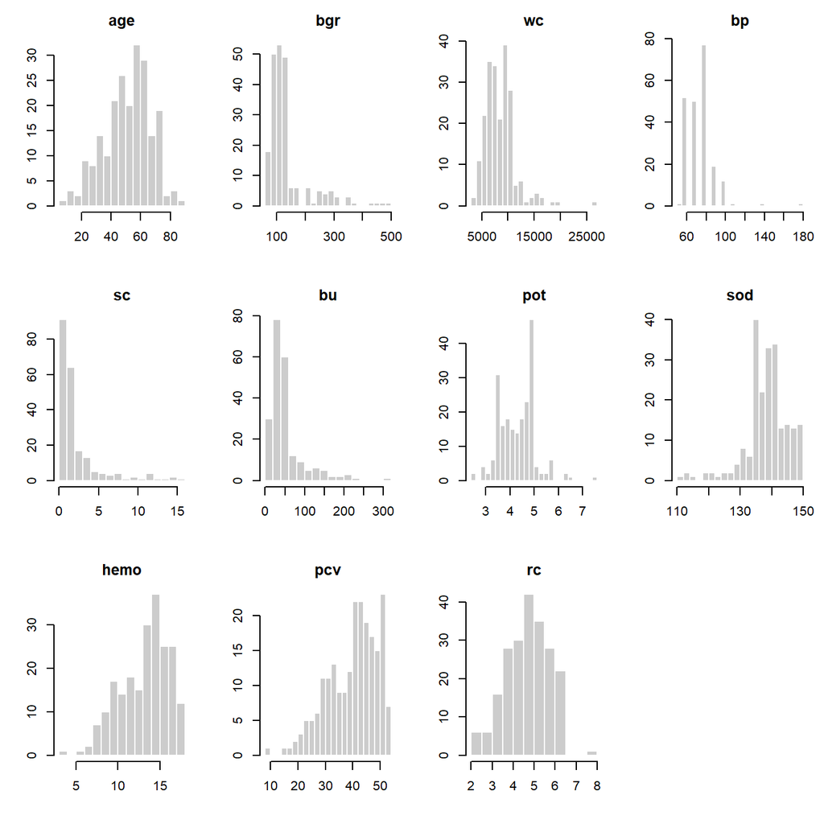

Distribución marginal de las once variables continuas.

Matriz de correlaciones de Pearson entre las once variables continuas.

|  | age | bgr | wc | bp | sc | bu | pot | sod | hemo | pcv | rc |
| --- | --- | --- | --- | --- | --- | --- | --- | --- | --- | --- | --- |
| age | 1.00 | 0.27 | 0.17 | 0.11 | 0.15 | 0.16 | 0.01 | -0.11 | -0.23 | -0.26 | -0.26 |
| bgr | 0.27 | 1.00 | 0.20 | 0.23 | 0.20 | 0.20 | -0.07 | -0.32 | -0.33 | -0.34 | -0.30 |
| wc | 0.17 | 0.20 | 1.00 | 0.06 | 0.08 | 0.10 | -0.09 | -0.17 | -0.29 | -0.29 | -0.21 |
| bp | 0.11 | 0.23 | 0.06 | 1.00 | 0.29 | 0.19 | 0.02 | -0.18 | -0.32 | -0.35 | -0.25 |
| sc | 0.15 | 0.20 | 0.08 | 0.29 | 1.00 | 0.86 | 0.21 | -0.48 | -0.66 | -0.65 | -0.58 |
| bu | 0.16 | 0.20 | 0.10 | 0.19 | 0.86 | 1.00 | 0.23 | -0.46 | -0.65 | -0.64 | -0.56 |
| pot | 0.01 | -0.07 | -0.09 | 0.02 | 0.21 | 0.23 | 1.00 | 0.02 | -0.16 | -0.24 | -0.21 |
| sod | -0.11 | -0.32 | -0.17 | -0.18 | -0.48 | -0.46 | 0.02 | 1.00 | 0.52 | 0.52 | 0.42 |
| hemo | -0.23 | -0.33 | -0.29 | -0.32 | -0.66 | -0.65 | -0.16 | 0.52 | 1.00 | 0.87 | 0.78 |
| pcv | -0.26 | -0.34 | -0.29 | -0.35 | -0.65 | -0.64 | -0.24 | 0.52 | 0.87 | 1.00 | 0.78 |
| rc | -0.26 | -0.30 | -0.21 | -0.25 | -0.58 | -0.56 | -0.21 | 0.42 | 0.78 | 0.78 | 1.00 |

La prueba de Shapiro-Wilk rechaza la normalidad marginal en las once variables al nivel de significancia habitual. Las desviaciones son de dos tipos: por un lado, los marcadores de retención de solutos (`sc`, `bu`, `bgr`) y el conteo de leucocitos (`wc`) presentan asimetría positiva pronunciada, con distribuciones concentradas en valores bajos y colas largas hacia la derecha; por otro, los marcadores hematológicos (`hemo`, `pcv`, `rc`) y el sodio muestran asimetría negativa moderada.

Esta desviación debe interpretarse con precisión. Una GBN no exige normalidad marginal de cada variable, sino normalidad *condicional* de cada nodo dados sus padres; una variable marginalmente asimétrica puede ser condicionalmente normal si su asimetría proviene precisamente de la heterogeneidad inducida por sus padres. No obstante, la magnitud de la asimetría observada en `sc` y `bu` anticipa que el ajuste gaussiano será menos preciso en las colas, lo que resulta relevante al interpretar consultas formuladas sobre umbrales clínicos que se sitúan justamente en esas regiones de la distribución.

En cuanto a la estructura de dependencia, la matriz de correlaciones muestra un bloque hematológico fuertemente acoplado (`hemo`, `pcv` y `rc` con correlaciones superiores a 0.7 entre sí) y correlaciones negativas moderadas entre los marcadores de retención y ese bloque, patrón compatible con la anemia asociada al deterioro renal. El conteo de leucocitos (`wc`) presenta correlaciones débiles con el resto de variables, indicio temprano de que su integración en la red aportará poca información.

### Estructuras candidatas (DAGs)

Se realizaron entrevistas con tres personas del área de la salud del entorno cercano de los autores: la madre de una de las integrantes y la tía de otro, ambas médicas, y una prima de un tercer integrante, estudiante próxima a egresar de la carrera de Medicina. A cada una se le explicó el concepto de DAG y con ellas se construyó su estructura de manera conjunta, discutiendo la justificación clínica de cada relación de dependencia propuesta sobre las mismas once variables continuas.

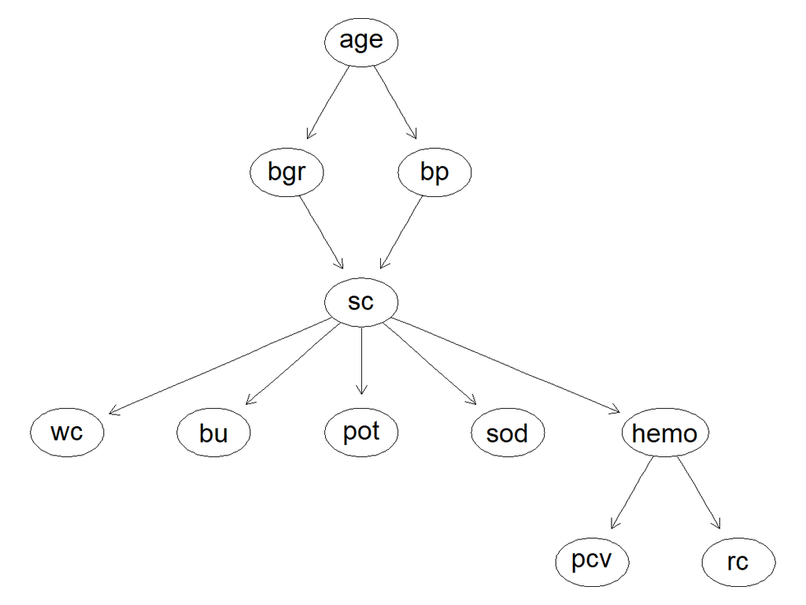

**DAG 1** — creatinina sérica como punto único de convergencia.

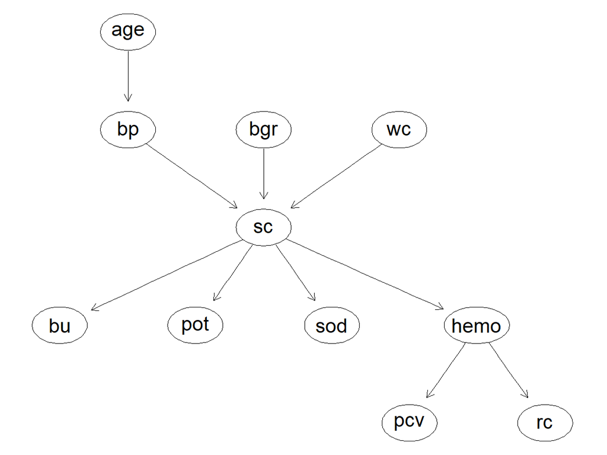

**DAG 2** — glucosa y leucocitos con incidencia directa sobre creatinina.

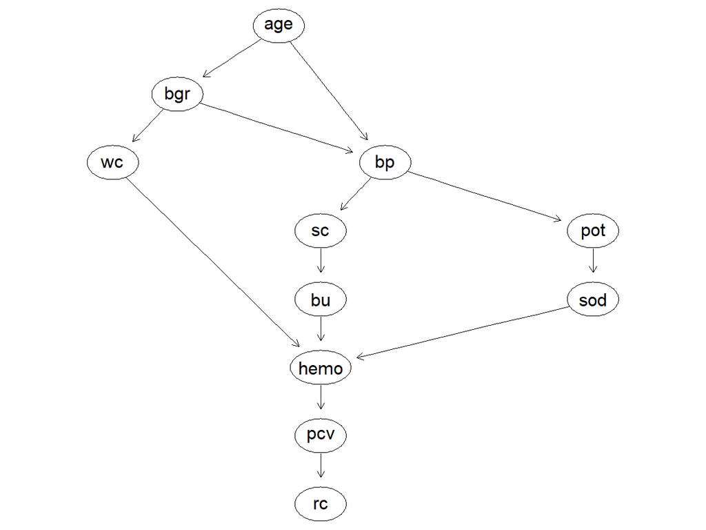

**DAG 3** — anemia renal como fenómeno multifactorial.

### Ajuste y evaluación de las Redes Bayesianas Gaussianas

Para cada una de las tres estructuras propuestas se ajustó una red bayesiana gaussiana mediante la función `bn.fit()` del paquete `bnlearn`, que estima los parámetros de cada distribución local por máxima verosimilitud. En una GBN, la distribución local de cada nodo corresponde a un modelo lineal gaussiano en el que los nodos padre actúan como variables explicativas: el nodo se distribuye normalmente con una media que es combinación lineal de sus padres y una varianza propia que no depende de ellos. Los nodos sin padres se modelan como distribuciones normales univariadas marginales.

Las tres redes se ajustaron sobre la misma submuestra de 214 casos completos. Esta condición es necesaria para que la comparación sea válida: tanto el BIC como el AIC dependen del tamaño muestral, de modo que ajustar cada estructura sobre un subconjunto distinto de observaciones produciría valores no comparables entre sí, y las diferencias reflejarían el cambio de muestra en lugar de la calidad de la estructura.

La evaluación se realizó mediante dos criterios de información. Ambos combinan la log-verosimilitud alcanzada por el modelo con una penalización que crece con el número de parámetros, de manera que un modelo con más arcos sólo obtiene mejor puntaje si la ganancia en ajuste supera el costo de la complejidad añadida. La diferencia entre ambos está en la severidad de esa penalización: el AIC penaliza cada parámetro con un peso constante, mientras que el BIC lo pondera por el logaritmo del tamaño muestral, resultando más estricto y favoreciendo estructuras más parsimoniosas.

Conviene señalar una particularidad de la implementación. La formulación de `bnlearn` corresponde a

$$\text{BIC}_{\texttt{bnlearn}} = \ell(\hat{\boldsymbol{\theta}}; \boldsymbol{x}) - \frac{k}{2}\log(n),$$

donde $\ell$ es la log-verosimilitud, $k$ el número de parámetros y $n$ el tamaño muestral. Al expresarse como la log-verosimilitud menos la penalización, y no como su negativo multiplicado por dos, un valor **mayor** indica mejor ajuste. Esta convención es opuesta a la de las funciones `BIC()` y `AIC()` de R base, y se mantiene de forma consistente en todas las tablas de este trabajo.

### Extensión con variables categóricas

Una GBN requiere que todos sus nodos sean continuos y normalmente distribuidos, por lo que las variables categóricas del conjunto de datos quedan excluidas del modelo principal. Sin embargo, esta restricción puede relajarse mediante las redes bayesianas condicional-gaussianas (CLG), que admiten nodos discretos y continuos en una misma estructura.

En una red CLG la coexistencia de ambos tipos de nodo no es arbitraria: las variables discretas sólo pueden ser nodos raíz o padres de nodos continuos, nunca hijos de ellos. La razón es que la distribución de un nodo continuo puede condicionarse a las categorías de un padre discreto —ajustando una distribución gaussiana distinta para cada combinación de niveles—, mientras que la operación inversa no está definida dentro de este marco. Los nodos continuos con padres discretos siguen entonces una distribución normal cuya media varía según el nivel del padre categórico.

Para explorar esta extensión se amplió la mejor estructura identificada con las dos comorbilidades más relevantes para la enfermedad renal crónica disponibles en el conjunto de datos: diabetes mellitus (`dm`) e hipertensión arterial (`htn`). Ambas se incorporaron como nodos raíz de tipo factor, conectados a los nodos continuos mediante cuatro arcos con sustento clínico: `dm` → `bgr`, dado que la diabetes se manifiesta directamente en niveles elevados de glucosa en sangre; `htn` → `bp`, puesto que la hipertensión se define por valores altos de presión arterial; y `dm` → `sc` junto con `htn` → `sc`, reflejando que ambas condiciones deterioran progresivamente la función renal y elevan la creatinina sérica.

El modelo mixto se ajustó con `bn.fit()` sobre 212 casos completos —dos menos que el modelo principal, debido a registros con valores faltantes en las variables categóricas— y se evaluó con los criterios `bic-cg` y `aic-cg`, las versiones para redes condicional-gaussianas de los criterios empleados anteriormente. Para que la comparación fuera válida, la GBN gaussiana pura se reajustó sobre esa misma submuestra de 212 casos, de modo que ambos modelos comparten tamaño muestral.

### Modelos no paramétricos

La GBN impone que cada nodo hijo sea una combinación lineal de sus padres. Un modelo no paramétrico relaja ese supuesto: si $y$ es un nodo hijo y $\boldsymbol{x} = (x_1, \dots, x_p)$ son sus nodos padre, la relación se describe como

$$y \sim \text{N}\left(f_1(x_1) + \dots + f_p(x_p),\ \sigma^2\right),$$

donde cada $f_j(\cdot)$ es una función suave desconocida del nodo padre $x_j$, estimada a partir de los datos en lugar de fijarse como un coeficiente lineal. La forma de la relación deja así de imponerse a priori y pasa a determinarse por la evidencia disponible.

Estas funciones suaves se construyen mediante splines. Un spline es una función definida por pedazos, típicamente polinomios de grado tres unidos en puntos de corte, que resulta de la suma ponderada de un conjunto de funciones base. El número de funciones base determina la flexibilidad máxima de la curva.

Se ajustó un modelo aditivo generalizado (GAM) para cada nodo con padres mediante la función `gam()` del paquete `mgcv`, empleando `method = "REML"` para la estimación de los parámetros de suavizado. El nodo raíz (`age`), al carecer de padres, se modeló como una distribución gaussiana univariada. El BIC y el AIC de la red completa se obtuvieron como la suma de los scores de las distribuciones locales, procedimiento válido porque la log-verosimilitud conjunta se factoriza según la estructura de la DAG.

La construcción de los splines encontró una restricción en la variable `bp`. Al tratarse de una medición clínica registrada en múltiplos de diez, toma únicamente nueve valores distintos en la muestra, por debajo de la base de diez funciones que emplea `mgcv` por defecto. La base correspondiente se redujo en consecuencia a $k = 8$. Se trata de una limitación impuesta por la resolución del dato y no por el método: ninguna técnica flexible puede recuperar estructura que la variable no registra.

Respecto a la escala de los criterios de información, las funciones `BIC()` y `AIC()` de R base emplean la convención $\text{BIC}_R = -2\ell + k\log(n)$, en la que un valor menor indica mejor ajuste, mientras que `score()` de `bnlearn` utiliza la formulación descrita anteriormente. Ambas se relacionan mediante $\text{BIC}_{\texttt{bnlearn}} = -\text{BIC}_R/2$, por lo que los scores del modelo no paramétrico se convirtieron a la escala de `bnlearn` y resultan directamente comparables con los reportados en las secciones previas.

La conversión se verificó recalculando el BIC del modelo lineal por ambas vías, obteniendo $-8799.85$ mediante `BIC()` convertido frente a $-8799.90$ mediante `score()`. La discrepancia de 0.05 unidades se explica porque `bnlearn` estima la varianza de cada nodo con denominador insesgado, mientras que `logLik()` de R emplea el estimador de máxima verosimilitud.

Finalmente, dado que un criterio de información agregado puede ocultar comportamientos heterogéneos entre nodos, se realizaron dos análisis complementarios. Por un lado, el BIC se descompuso por distribución local para identificar en qué nodos la introducción del término suave mejora efectivamente el ajuste y en cuáles lo deteriora. Por otro, se llevó a cabo una validación cruzada de diez particiones que compara el error de predicción fuera de muestra de cada nodo bajo ambos enfoques. Esta última resulta pertinente porque tanto el BIC como el AIC se calculan dentro de muestra: aunque penalizan la complejidad, no garantizan que la flexibilidad añadida se traduzca en mejor capacidad predictiva sobre observaciones no observadas. La combinación de ambos análisis permite distinguir la no linealidad genuina del sobreajuste.

### Consultas (queries)

Cada especialista entrevistada propuso dos consultas de interés clínico que pudieran resolverse mediante el modelo, para un total de seis.

**Consultas propuestas por la primera especialista:**

- **Q1.** Probabilidad de que la creatinina sérica supere 1.5 mg/dL en un paciente con presión arterial de 100 mmHg y glucosa en sangre de 150 mg/dL:
  $$P(sc > 1.5 \mid bp = 100,\ bgr = 150)$$
- **Q2.** Probabilidad de que la hemoglobina sea inferior a 10 g/dL, indicativa de anemia, en un paciente de 65 años:
  $$P(hemo < 10 \mid age = 65)$$

**Consultas propuestas por la segunda especialista:**

- **Q3.** Probabilidad de que el conteo de glóbulos blancos supere 11,000 células/mm³ en un paciente con hematocrito reducido:
  $$P(wc > 11000 \mid pcv = 28)$$
- **Q4.** Probabilidad de que el potasio supere 5.5 mEq/L, umbral de hipercalemia, en un paciente con creatinina sérica de 2.2 mg/dL y urea en sangre de 45 mg/dL:
  $$P(pot > 5.5 \mid sc = 2.2,\ bu = 45)$$

**Consultas propuestas por la tercera especialista:**

- **Q5.** Probabilidad de que el hematocrito sea inferior a 33% en un paciente con urea de 60 mg/dL, sodio de 130 mEq/L y conteo de glóbulos blancos de 11,000 células/mm³:
  $$P(pcv < 33 \mid bu = 60,\ sod = 130,\ wc = 11000)$$
- **Q6.** Probabilidad de un conteo bajo de glóbulos rojos, por debajo de 3.8 millones/µL, en un paciente cuya hemoglobina ha descendido a 9.5 g/dL:
  $$P(rc < 3.8 \mid hemo = 9.5)$$

Las consultas se resolvieron sobre la estructura con mejor ajuste mediante inferencia aproximada por simulación, empleando la función `cpquery()` de `bnlearn` con el método de *likelihood weighting*. Cada consulta se estimó con $10^6$ muestras y una semilla fija, de modo que los resultados sean reproducibles pese a la naturaleza estocástica del procedimiento.

El método de *likelihood weighting* requiere que la evidencia sobre nodos continuos se exprese como valores puntuales y no como intervalos. La consulta Q3 fue formulada originalmente por la especialista en términos de un hematocrito inferior a 30%; para su resolución se adoptó $pcv = 28$ como valor puntual representativo de esa condición. Esta sustitución es una aproximación operativa que debe tenerse presente al interpretar el resultado correspondiente.

Antes de resolver las consultas se verificó que en todos los casos la evidencia estuviera d-conectada con la variable objetivo dentro de la DAG 1, condición necesaria para que el condicionamiento resulte informativo. Adicionalmente, cada probabilidad condicional se contrastó con la probabilidad marginal del mismo evento, calculada sin evidencia alguna. Esta comparación permite cuantificar cuánto desplaza efectivamente la evidencia a la creencia sobre el evento, un aspecto que la conectividad estructural por sí sola no determina.

## Resultados

### Comparación de BIC y AIC entre estructuras

BIC y AIC de las tres GBN ajustadas sobre los mismos 214 casos completos.

| Estructura | Arcos | BIC | AIC |
| --- | --- | --- | --- |
| DAG 1 (creatinina como convergencia única) | 11 | -8799.90 | -8744.37 |
| DAG 2 (glucosa y leucocitos directos) | 10 | -8805.68 | -8751.82 |
| DAG 3 (anemia multifactorial) | 13 | -8814.43 | -8755.52 |

### Resultados de las consultas

Resultados de las seis consultas sobre la DAG 1, contrastados con la probabilidad marginal del evento. El desplazamiento cuantifica el aporte informativo de la evidencia.

| Consulta | Expresión | Marginal | Condicional | Desplazamiento |
| --- | --- | --- | --- | --- |
| Q1 | $P(sc > 1.5 \mid bp = 100,\ bgr = 150)$ | 0.6042 | 0.7749 | +0.1707 |
| Q2 | $P(hemo < 10 \mid age = 65)$ | 0.1318 | 0.1395 | +0.0077 |
| Q3 | $P(wc > 11000 \mid pcv = 28)$ | 0.2003 | 0.2180 | +0.0177 |
| Q4 | $P(pot > 5.5 \mid sc = 2.2,\ bu = 45)$ | 0.0652 | 0.0601 | -0.0052 |
| Q5 | $P(pcv < 33 \mid bu = 60,\ sod = 130,\ wc = 11000)$ | 0.2075 | 0.2347 | +0.0272 |
| Q6 | $P(rc < 3.8 \mid hemo = 9.5)$ | 0.1777 | 0.5492 | +0.3715 |

Las seis consultas se resolvieron sobre la DAG 1. Los resultados son: Q1 $= 0.7749$, Q2 $= 0.1395$, Q3 $= 0.2180$, Q4 $= 0.0601$, Q5 $= 0.2347$ y Q6 $= 0.5492$.

El desplazamiento respecto a la probabilidad marginal varía de manera pronunciada entre consultas. Q6 registra el mayor desplazamiento ($+0.3715$, de $0.1777$ a $0.5492$), seguida de Q1 ($+0.1707$, de $0.6042$ a $0.7749$). En el extremo opuesto, Q2 ($+0.0077$), Q3 ($+0.0177$), Q5 ($+0.0272$) y Q4 ($-0.0052$) presentan desplazamientos inferiores a tres centésimas.

Para Q4 se calculó adicionalmente la probabilidad condicionando únicamente en la creatinina sérica, obteniendo $P(pot > 5.5 \mid sc = 2.2) = 0.0601$, valor idéntico al obtenido con la evidencia completa.

### Modelo mixto con variables categóricas

Comparación entre la GBN gaussiana pura y la red condicional-gaussiana, ambas ajustadas sobre los mismos 212 casos completos.

| Modelo | Nodos | Arcos | BIC | AIC |
| --- | --- | --- | --- | --- |
| GBN gaussiana (DAG 1) | 11 | 11 | -8724.64 | -8669.26 |
| Red condicional-gaussiana (DAG 1 + $dm$ + $htn$) | 13 | 15 | -8801.21 | -8712.26 |

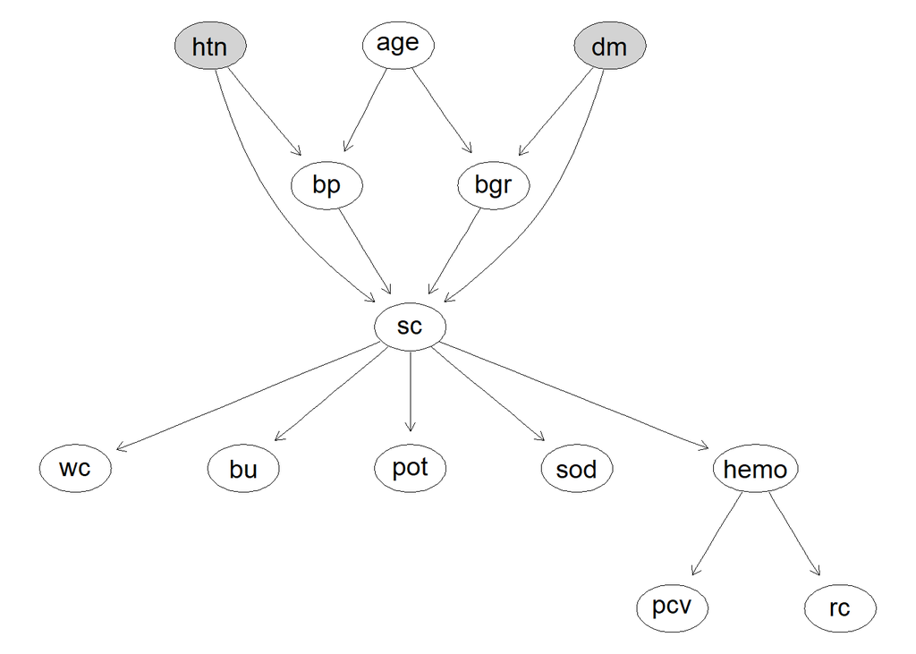

**DAG mixta** — DAG 1 extendida con los nodos categóricos de diabetes e hipertensión.

Sobre los mismos 212 casos, la GBN gaussiana pura obtuvo BIC $-8724.64$ y AIC $-8669.26$, frente a BIC $-8801.21$ y AIC $-8712.26$ de la red condicional-gaussiana. La incorporación de las dos comorbilidades deterioró el BIC en 76.57 puntos y el AIC en 43.00 puntos.

En cuanto a la inferencia, la probabilidad de creatinina elevada asciende a $P(sc > 1.5 \mid dm = \text{sí},\ htn = \text{sí}) = 0.7835$ en un paciente con ambas comorbilidades, frente a $P(sc > 1.5 \mid dm = \text{no},\ htn = \text{no}) = 0.4070$ en un paciente sin ninguna.

### Modelos no paramétricos

Comparación entre la GBN lineal y el modelo no paramétrico basado en splines, en la escala de bnlearn (mayor es mejor).

| Modelo | BIC | AIC |
| --- | --- | --- |
| GBN lineal (DAG 1) | -8799.85 | -8744.31 |
| Modelo no parametrico GAM/splines (DAG 1) | -8740.56 | -8606.15 |

Grados de libertad efectivos de cada término suave. Un valor cercano a 1 indica una relación esencialmente lineal.

| Nodo | Término | edf | valor $p$ |
| --- | --- | --- | --- |
| bp | s(age) | 1.636 | 0.1949 |
| bgr | s(age) | 3.803 | 0.0001 |
| sc | s(bp) | 4.016 | 0.0000 |
| sc | s(bgr) | 4.025 | 0.0122 |
| bu | s(sc) | 8.384 | 0.0000 |
| sod | s(sc) | 3.468 | 0.0000 |
| pot | s(sc) | 4.870 | 0.0013 |
| wc | s(sc) | 4.174 | 0.0035 |
| hemo | s(sc) | 4.602 | 0.0000 |
| pcv | s(hemo) | 6.609 | 0.0000 |
| rc | s(hemo) | 4.512 | 0.0000 |

Descomposición de la mejora del BIC por distribución local. Un valor positivo indica que el término suave mejora el ajuste de ese nodo.

| Nodo | BIC lineal | BIC GAM | Mejora |
| --- | --- | --- | --- |
| pcv | -632.22 | -602.45 | 29.76 |
| hemo | -477.91 | -453.57 | 24.34 |
| rc | -219.37 | -211.39 | 7.98 |
| bu | -979.30 | -971.92 | 7.38 |
| sod | -694.60 | -693.85 | 0.74 |
| sc | -531.36 | -531.91 | -0.55 |
| wc | -2016.31 | -2017.29 | -0.98 |
| bp | -879.51 | -881.53 | -2.02 |
| bgr | -1229.78 | -1232.65 | -2.87 |
| pot | -243.69 | -248.18 | -4.49 |

Error de predicción fuera de muestra por nodo, validación cruzada de diez particiones.

| Nodo | RMSE lineal | RMSE GAM | Mejora (%) |
| --- | --- | --- | --- |
| pcv | 4.494 | 3.712 | 17.4 |
| hemo | 2.201 | 1.912 | 13.1 |
| rc | 0.655 | 0.610 | 6.8 |
| bgr | 73.296 | 71.496 | 2.5 |
| wc | 2961.101 | 2895.711 | 2.2 |
| sod | 6.061 | 5.964 | 1.6 |
| bp | 14.318 | 14.362 | -0.3 |
| pot | 0.760 | 0.770 | -1.4 |
| bu | 23.134 | 24.571 | -6.2 |
| sc | 2.869 | 3.640 | -26.9 |

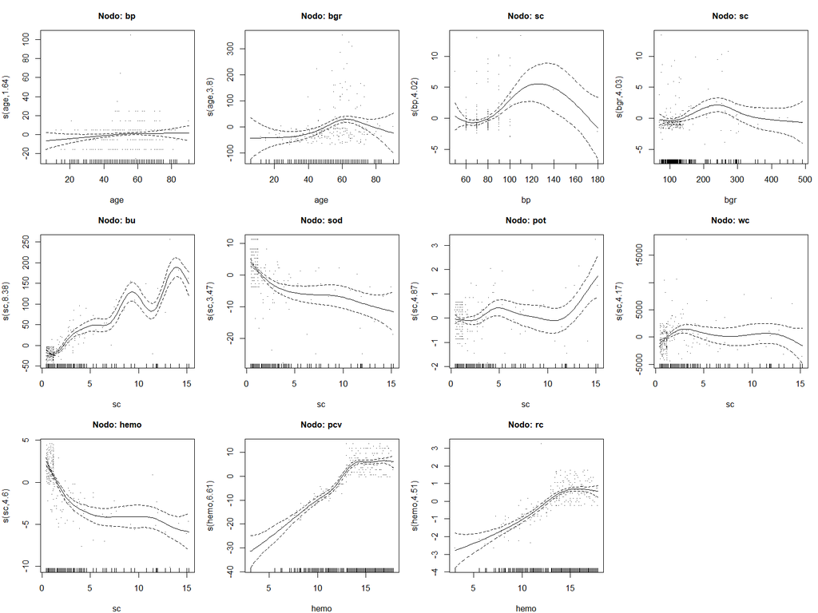

Efectos parciales estimados para cada término suave del modelo no paramétrico.

El modelo no paramétrico obtuvo un BIC de $-8740.56$ frente a $-8799.85$ del modelo lineal, una mejora de 59.29 puntos, y un AIC de $-8606.15$ frente a $-8744.31$, una mejora de 138.16 puntos.

Todos los términos suaves resultaron significativos ($p < 0.05$), con la única excepción de $s(age)$ en el nodo `bp` ($p = 0.1949$). Los grados de libertad efectivos oscilan entre 1.636, para `bp` ~ `age`, y 8.384, para `bu` ~ `sc`.

La descomposición del BIC por distribución local muestra que el término suave mejora el ajuste en 5 de los 10 nodos con padres. Los nodos que mejoran suman 70.20 puntos —`pcv` ($+29.76$), `hemo` ($+24.34$), `rc` ($+7.98$), `bu` ($+7.38$) y `sod` ($+0.74$)— mientras que los cinco restantes lo deterioran en 10.91 puntos —`pot` ($-4.49$), `bgr` ($-2.87$), `bp` ($-2.02$), `wc` ($-0.98$) y `sc` ($-0.55$)—, resultando en la mejora neta de 59.29 puntos.

En validación cruzada, el modelo no paramétrico redujo el error de predicción fuera de muestra en 6 de los 10 nodos, con las mayores reducciones en `pcv` (17.4%), `hemo` (13.1%) y `rc` (6.8%), y los mayores incrementos de error en `sc` (26.9%) y `bu` (6.2%).

## Discusión

### Comparación de estructuras

La evaluación cuantitativa situó a la **DAG 1** como la estructura con mejor ajuste en ambos criterios de información. La diferencia de 14.53 puntos en BIC respecto a la **DAG 3** evidencia que una mayor densidad de arcos no se traduce necesariamente en una representación más fiel del fenómeno subyacente: la DAG 3, pese a incorporar 13 arcos que reflejan una concepción multifactorial de la anemia renal, fue penalizada por el costo paramétrico de sus dependencias adicionales sin obtener a cambio una ganancia proporcional en verosimilitud.

Conviene precisar el alcance de esta conclusión. Las tres estructuras difieren en pocos arcos y las diferencias de BIC entre ellas son modestas en relación con la magnitud absoluta del criterio. El resultado indica una preferencia por la DAG 1 dentro del conjunto evaluado, no que esa estructura sea la representación correcta del proceso fisiopatológico: existe un número enorme de DAGs posibles sobre once variables, y sólo se compararon tres.

El elemento arquitectónico determinante en el desempeño de la DAG 1 es la posición de la creatinina sérica (`sc`) como punto único de convergencia, topología coherente con la fisiopatología renal. La creatinina sérica es el biomarcador primario empleado para estimar la tasa de filtración glomerular, de modo que factores de riesgo como la edad, la presión arterial y la glucosa convergen en el deterioro de la capacidad de filtrado. A su vez, ese daño desencadena las complicaciones sistémicas subsiguientes: la retención de solutos nitrogenados y la falla en la síntesis renal de eritropoyetina, que impacta sobre el eje hematológico. La DAG 1 captura esta cascada con una parsimonia que los criterios de información recompensan.

Un matiz relevante afecta a uno de los arcos de esta estructura. El arco `sc` → `wc`, propuesto por la primera especialista, no alcanza significancia estadística en la muestra ($p = 0.246$, $R^2 = 0.006$), lo que concuerda con las correlaciones débiles del conteo de leucocitos observadas en la exploración inicial. La leucocitosis en la ERC responde más a procesos inflamatorios o infecciosos concurrentes que al grado de deterioro del filtrado, por lo que su dependencia directa de la creatinina no encuentra respaldo empírico en estos datos.

### Interpretación de las consultas

Las seis consultas resultaron resolubles sobre la DAG 1: en todos los casos existe al menos un camino activo entre la evidencia y la variable objetivo. Sin embargo, los resultados revelan que la d-conexión estructural es condición necesaria pero no suficiente para que la evidencia sea informativa. El contraste sistemático entre cada probabilidad condicional y su marginal muestra dos regímenes claramente diferenciados.

**Consultas con evidencia informativa.** Q6 y Q1 concentran los mayores desplazamientos, y en ambas la evidencia recae sobre padres directos del nodo objetivo:

- **Q6** ($P(rc < 3.8 \mid hemo = 9.5) = 0.5492$, marginal $0.1777$): ante una caída de hemoglobina a 9.5 g/dL, la probabilidad de un conteo disminuido de glóbulos rojos se triplica. El desplazamiento de $+0.3715$ es el mayor de las seis consultas y refleja el acoplamiento estrecho entre hemoglobina y masa eritrocitaria, cuya correlación en la muestra supera 0.7. Clínicamente el resultado es esperable: ambos parámetros miden facetas del mismo fenómeno hematológico.
- **Q1** ($P(sc > 1.5 \mid bp = 100,\ bgr = 150) = 0.7749$, marginal $0.6042$): la probabilidad de creatinina alterada supera el 77% en un paciente con presión arterial de 100 mmHg y glucosa de 150 mg/dL. Cabe precisar la lectura clínica de esta cifra: en este conjunto de datos la presión arterial se registra con una mediana de 80 mmHg y valores concentrados entre 60 y 80, lo que sugiere que corresponde a presión diastólica. Bajo esa lectura, 100 mmHg constituye hipertensión y no un valor normal, de modo que la consulta describe a un paciente con ambos factores de riesgo simultáneamente elevados —hipertensión e hiperglucemia—, escenario en el que una probabilidad elevada de daño renal resulta consistente con la literatura.

**Consultas con evidencia poco informativa.** Q2, Q3, Q4 y Q5 desplazan la probabilidad en menos de tres centésimas, por razones distintas en cada caso:

- **Q4** ($P(pot > 5.5 \mid sc = 2.2,\ bu = 45) = 0.0601$, marginal $0.0652$): pese a que `sc` es padre directo de `pot`, la relación entre ambos es débil en la muestra ($R^2 = 0.046$), de modo que conocer la creatinina apenas modifica la creencia sobre el potasio. El resultado clínico —probabilidad baja de hipercalemia franca— es congruente con que en estadios moderados de ERC los mecanismos compensatorios de secreción tubular preservan la normocalemia, reservando la hipercalemia grave para estadios avanzados. Adicionalmente, al condicionar únicamente en `sc` se obtiene exactamente el mismo valor ($0.0601$), confirmando empíricamente que la evidencia sobre `bu` es redundante: ambos son hijos de `sc` y condicionar en su padre común los d-separa entre sí.
- **Q3** ($P(wc > 11000 \mid pcv = 28) = 0.2180$, marginal $0.2003$): la evidencia sobre el hematocrito alcanza al conteo de leucocitos por la trayectoria $wc \leftarrow sc \rightarrow hemo \rightarrow pcv$, activa al no estar condicionados los nodos intermedios. El desplazamiento es pequeño porque la información debe atravesar tres arcos y, sobre todo, porque el arco terminal `sc` → `wc` carece de fuerza estadística según se discutió arriba.
- **Q5** ($P(pcv < 33 \mid bu = 60,\ sod = 130,\ wc = 11000) = 0.2347$, marginal $0.2075$): la evidencia sobre tres hermanos de `hemo` informa indirectamente sobre `pcv` a través del ancestro común `sc`. El desplazamiento, aunque modesto, es el mayor de este grupo, lo que resulta razonable al provenir de tres fuentes de evidencia simultáneas.
- **Q2** ($P(hemo < 10 \mid age = 65) = 0.1395$, marginal $0.1318$): la edad influye sobre la hemoglobina únicamente a través de una cadena de tres arcos que pasa por la presión arterial o la glucosa y luego por la creatinina. El desplazamiento casi nulo tiene una lectura clínica directa: el envejecimiento por sí solo, sin evidencia de deterioro renal, no predice anemia. La anemia de la ERC es consecuencia del daño renal establecido y no del envejecimiento aislado.

**Implicación metodológica.** Este patrón ilustra un fenómeno general en las redes bayesianas: la influencia informativa se atenúa con la distancia en el grafo y con la debilidad de los arcos intermedios. Una consulta puede ser formalmente resoluble y aun así arrojar una respuesta prácticamente idéntica a la creencia previa. Reportar únicamente la probabilidad condicional, sin su marginal de referencia, ocultaría esta distinción y podría sugerir que la evidencia resultó relevante cuando no lo fue. Por ello se reportan ambas cantidades de forma sistemática.

### Variables categóricas

La incorporación de las comorbilidades `dm` (diabetes) e `htn` (hipertensión) en la red condicional-gaussiana deterioró ambos criterios de información: el BIC descendió de $-8724.64$ a $-8801.21$ sobre la misma submuestra de 212 casos. La explicación más directa es el costo paramétrico: en una red CLG, condicionar un nodo continuo sobre padres discretos exige estimar parámetros gaussianos independientes para cada combinación de niveles, de modo que `sc`, con dos padres categóricos binarios, multiplica por cuatro sus parámetros de media.

Conviene no sobreinterpretar este resultado. El deterioro del criterio es compatible con dos explicaciones que este análisis no distingue: que la penalización paramétrica supere una ganancia real en verosimilitud, o que `dm` y `htn` aporten poca información adicional una vez que `bgr` y `bp` —sus manifestaciones cuantitativas directas— ya forman parte de la red. Esta segunda posibilidad resulta plausible precisamente por la construcción de los arcos: la glucosa en sangre es la expresión medible de la diabetes, y la presión arterial lo es de la hipertensión, de modo que las variables categóricas podrían ser en buena medida redundantes respecto a las continuas ya presentes.

No obstante, la inferencia sobre la red CLG demostró utilidad clínica. La probabilidad de creatinina elevada casi se duplica, pasando del 40.70% en pacientes sin comorbilidades al 78.35% en pacientes con diagnóstico concurrente de ambas. Esta capacidad de estratificación es valiosa en la práctica, donde el diagnóstico de diabetes o hipertensión suele estar disponible antes que un panel bioquímico completo. El caso ilustra la tensión entre la optimización estadística por parsimonia y la utilidad operativa: un modelo puede empeorar en criterios de información y seguir siendo preferible para un uso clínico concreto.

### Modelos no paramétricos

La relajación del supuesto de linealidad mediante splines mejoró los criterios agregados en 59.29 puntos de BIC y 138.16 de AIC. La descomposición por distribución local revela, sin embargo, que esa mejora no es homogénea y que leerla como una superioridad global del enfoque flexible sería incorrecto.

**Sobreajuste inducido por asimetría.** En cinco nodos el término suave deteriora el BIC, y el caso más agudo aparece en `sc` ~ `bp` + `bgr`, donde la validación cruzada registra un error de predicción 26.9% mayor que el del modelo lineal. La explicación se encuentra en la distribución de la creatinina sérica documentada en la exploración inicial: fuertemente sesgada a la derecha, con mediana de 1.15 mg/dL frente a un máximo de 15.2 y escasas observaciones en la cola superior. El spline ajusta esos pocos valores extremos en lugar de una tendencia subyacente, y el resultado no generaliza.

**El caso ambiguo de `bu`.** Este nodo mejora el BIC ($+7.38$) pero empeora en validación cruzada ($-6.2\%$), y presenta el mayor número de grados de libertad efectivos de todo el modelo ($edf = 8.384$). La combinación sugiere que el spline captura estructura dentro de muestra que no se sostiene fuera de ella. El caso resulta ilustrativo: si sólo se hubiera consultado el criterio de información, la conclusión habría sido que la relación entre creatinina y urea es marcadamente no lineal, cuando la evidencia predictiva apunta en dirección contraria.

**Límite impuesto por el dato.** El término $s(age)$ sobre `bp` fue el único no significativo ($edf = 1.636$, $p = 0.1949$), indicando que la relación entre edad y presión arterial es esencialmente lineal en esta cohorte. A ello se suma la baja resolución de la variable, registrada en múltiplos de diez y con sólo nueve valores distintos: ninguna técnica flexible puede recuperar estructura que la medición no registra.

En conjunto, estos hallazgos indican que la arquitectura más adecuada no es puramente flexible ni puramente lineal, sino mixta: el uso de splines encuentra justificación en las relaciones del eje hematológico y no en las dependencias metabólicas y vasculares.

### Articulación de los hallazgos

Las dos extensiones exploradas apuntan en direcciones distintas y su contraste resulta informativo. La incorporación de comorbilidades categóricas no mejoró los criterios de información, aunque ofreció una estratificación clínica del riesgo de valor práctico. La flexibilización de la forma funcional sí mejoró el ajuste agregado, si bien de manera concentrada en una región específica de la red.

La lectura conjunta sugiere que la principal restricción de la GBN sobre estos datos no residía en la omisión de variables causales —añadir diabetes e hipertensión no aportó ajuste— sino en la imposición de linealidad sobre la cascada de complicaciones hematológicas. Esta interpretación es coherente con la exploración inicial, donde el bloque hematológico mostraba las correlaciones más fuertes de todo el conjunto, y con el análisis de consultas, donde precisamente los desplazamientos probabilísticos más pronunciados se produjeron en ese mismo eje.

### Limitaciones

El estudio presenta cinco limitaciones principales que deben considerarse al interpretar los resultados:

1. **Pérdida de datos por casos completos.** La restricción a registros sin valores faltantes redujo la muestra de 400 a 214 casos, una pérdida del 46.5% concentrada en variables hematológicas y electrolitos. Si el patrón de ausencia no cumple el supuesto de faltantes completamente al azar (MCAR), el análisis podría estar sujeto a sesgo de selección. Dado que las variables con mayor proporción de faltantes son precisamente las del eje hematológico, sobre el que descansan varias de las conclusiones, esta limitación merece atención particular.
2. **Tamaño muestral.** Un total de 214 observaciones resulta moderado para la estimación simultánea de once distribuciones locales continuas y sus parámetros de varianza.
3. **Incumplimiento del supuesto de normalidad.** Las once variables rechazan la normalidad marginal, con asimetrías pronunciadas en los marcadores de retención. Aunque la GBN exige normalidad condicional y no marginal, la magnitud de las desviaciones observadas sugiere que el ajuste es menos preciso en las colas de las distribuciones, justamente donde se sitúan los umbrales clínicos de varias consultas.
4. **Construcción de las estructuras.** Las DAGs candidatas derivan de entrevistas individuales con tres personas del área de la salud del entorno cercano de los autores, en lugar de una metodología formal de consenso con nefrólogos especialistas. Sólo se compararon tres estructuras de un espacio combinatorio muy amplio.
5. **Validez externa.** El conjunto de datos no especifica el origen geográfico ni la composición de la población muestreada, lo que restringe la extrapolación de los umbrales numéricos a otros entornos clínicos.

## Conclusiones

**Selección de la estructura.** La red bayesiana gaussiana construida sobre la DAG 1 —que ubica a la creatinina sérica como punto de convergencia entre los factores de riesgo iniciales y las complicaciones secundarias— obtuvo el mejor ajuste de las tres estructuras evaluadas en ambos criterios de información (BIC $-8799.90$, AIC $-8744.37$). El resultado muestra que una mayor densidad de arcos no garantiza mejor representación: la estructura con más dependencias fue la peor evaluada.

**Inferencia probabilística y aporte informativo de la evidencia.** Las seis consultas planteadas por las especialistas resultaron resolubles sobre la mejor estructura. El contraste sistemático de cada probabilidad condicional con su marginal reveló que la relevancia de la evidencia varía en un orden de magnitud según su proximidad estructural al nodo objetivo: la evidencia sobre padres directos desplazó la probabilidad hasta en 0.37 unidades, mientras que la evidencia separada por tres arcos apenas la modificó. Este análisis, ausente si sólo se reportaran las probabilidades condicionales, permite distinguir entre consultas informativas y consultas formalmente correctas pero de escaso contenido.

**Variables categóricas.** La extensión condicional-gaussiana con diabetes e hipertensión deterioró los criterios de información, aunque permitió estratificar el riesgo de forma clínicamente útil: la probabilidad de creatinina elevada pasó del 40.70% en ausencia de comorbilidades al 78.35% con ambas presentes. El caso ilustra que el mejor modelo según criterios de parsimonia no coincide necesariamente con el más útil para una aplicación concreta.

**Modelado no paramétrico.** La relajación de la linealidad mediante splines mejoró el BIC agregado en 59.29 puntos, pero la descomposición por nodo y la validación cruzada mostraron que la ganancia se concentra en el eje hematológico y que en los nodos con distribuciones fuertemente sesgadas el modelo flexible sobreajusta. La arquitectura más adecuada para estos datos es por tanto híbrida: relaciones flexibles para la respuesta hematológica y relaciones lineales para los marcadores metabólicos y vasculares.

## Referencias

Diabetes.org (American Diabetes Association). (s.f.). *Diabetes, presión arterial alta y enfermedad renal crónica (ERC)*. Recuperado el 5 de septiembre de 2026, de https://diabetes.org/es/sobre-la-diabetes/complicaciones/enfermedad-renal-cronica/diabetes-presion-arterial-alta-enfermedad-renal-cronica

Kidney Disease: Improving Global Outcomes (KDIGO) Anemia Work Group. (2012). KDIGO Clinical Practice Guideline for Anemia in Chronic Kidney Disease. *Kidney International Supplements*, 2(4), 279–335. https://doi.org/10.1038/kisup.2012.33

Koller, D., & Friedman, N. (2009). *Probabilistic Graphical Models: Principles and Techniques*. MIT Press.

Kovesdy, C. P. (2014). Management of hyperkalemia in chronic kidney disease. *Nature Reviews Nephrology*, 10(11), 653–662. https://doi.org/10.1038/nrneph.2014.168

National Kidney Foundation. (2024, 8 de noviembre). *La hipertensión arterial y la diabetes: dos enemigos silenciosos para tus riñones*. Kidney.org. https://www.kidney.org/es/news-stories/la-hipertension-arterial-y-la-diabetes-dos-enemigos-silenciosos-para-tus-rinones

Organización Panamericana de la Salud. (2014, 11 de marzo). *Crece el número de enfermos renales entre los mayores de 60 años con diabetes e hipertensión*. OPS/OMS. https://www.paho.org/es/noticias/11-3-2014-crece-numero-enfermos-renales-entre-mayores-60-anos-con-diabetes-e-hipertension

Rubini, L., Soundarapandian, P., & Eswaran, P. (2015). *Chronic Kidney Disease* [Conjunto de datos]. UCI Machine Learning Repository. https://doi.org/10.24432/C5G020

Scutari, M. (2010). Learning Bayesian Networks with the bnlearn R Package. *Journal of Statistical Software*, 35(3), 1–22. https://doi.org/10.18637/jss.v035.i03

Serna-Soto, J. L., Ortega-Mendoza, R. A. de J., Rivera-Ramírez, O. A., & Pérez-Peláez, G. C. (2016). Prevalencia de enfermedad renal crónica en pacientes con diabetes mellitus e hipertensión arterial en el Hospital Escandón. *Salud Pública de México*, 58(3), 338–339. https://doi.org/10.21149/spm.v58i3.7918

Thomas, R., Kanso, A., & Sedor, J. R. (2008). Chronic kidney disease and its complications. *Primary Care: Clinics in Office Practice*, 35(2), 329–344. https://doi.org/10.1016/j.pop.2008.01.008

Vertigo Político. (2022). *Los principales responsables de la enfermedad renal crónica son la diabetes y la hipertensión arterial*. https://www.vertigopolitico.com/bienestar/notas/los-principales-responsables-la-enfermedad-renal-cronica-son-la-diabetes-y

Wood, S. N. (2017). *Generalized Additive Models: An Introduction with R* (2nd ed.). CRC Press. https://doi.org/10.1201/9781315370279

[Repositorio del proyecto](https://github.com/RafaelHeredia12/ARTICULO-2)